# Model

Fraud is a problem for any bank. Fraud can take many forms, whether it is someone stealing a single credit card, to large batches of stolen credit card numbers being used on the web, or even a mass compromise of credit card numbers stolen from a merchant via tools like credit card skimming devices.

- Each of the transactions in the dataset has a field called isFraud. Please build a predictive model to determine whether a given transaction will be fraudulent or not. Use as much of the data as you like (or all of it).
- Provide an estimate of performance using an appropriate sample, and show your work.
- Please explain your methodology (modeling algorithm/method used and why, what features/data you found useful, what questions you have, and what you would do next with more time)

# Imports

## Visualization, Data Wrangling, and Statistics

```python
# Data Wrangling
import pandas as pd
import numpy as np

# Visualization
import matplotlib.pyplot as plt
import seaborn as sns

# Statistical Analysis
from scipy import stats
from scipy.stats import fisher_exact, chi2_contingency
from distfit import distfit


# Utils
import os
from IPython.display import display

# Data loading and cleaning functions
from data_load_clean import get_transaction_data, clean_transation_data
```

## Machine Learning

```python
from sklearn.metrics import make_scorer
from sklearn.metrics import (PrecisionRecallDisplay,
                             precision_recall_curve,
                             average_precision_score,
                             confusion_matrix)
from sklearn.model_selection import StratifiedKFold
from sklearn.compose import ColumnTransformer
from sklearn.pipeline import Pipeline
from sklearn.impute import SimpleImputer
from sklearn.preprocessing import StandardScaler, OneHotEncoder
from sklearn.linear_model import LogisticRegressionCV
from sklearn.ensemble import RandomForestClassifier
from sklearn.svm import SVC
from sklearn.model_selection import GridSearchCV
```

# Load and Clean Data

```python
# Load and Clean data using scripts in data_clean_load.py
# These scripts were developed during the data cleaning and analysis process
df_raw = get_transaction_data()
df = clean_transation_data(df_raw)
```

# Conclusions from Modeling

The cells below document my evaluation approach, feature development, and model creation. Key points are summarize below:

- Holdout data for final testing was created before feature generation and assessments. Because fraud prediction occurs in real-time, the last two months of data were used a holdout set.
- Model evaluation focuses on predicting fraud, which is a relatively rare event. To evaluate model performance on the imbalanced dataset, I use two performance measures. The first is average precision score on the precision-recall curve, which is selected for its focus on the positive class. The second is a bespoke utility function that attempts to capture how the dynamics of the Capital One business model apply to this prediction task. That utility function draws from a literature review on the cost of fraud and Capital One’s approach to combatting it.
- Feature development and selection explores the relationships between fraud and a series of existing and created features. Features were visually inspected and evaluated statistically for their Features that describe transactions, their verification, past fraud, and account status show statistical relationships to fraud.
- Model development applies test two different models to predict fraud: Logistic Regression and Random Forest. All models are based on their scikit-learn implementation. Where computationally feasible, models hyper-parameters were tuned using cross-validation and performance was tested in a time series walk-forward test-train split. The best model was selected for evaluation on the hold out set. I also set up a support vector classifier with grid search hyper-parameter tuning as an example, although I was not able to run the model due to time and computation resource constraints.
- Evaluating the best model performing model on the holdout set provided and estimate of in-product model performance. My ability to iterate and refine the applied predictive modeling was limited due computational resources and time constraints. Due to those constraints, I focused on the evaluation framework and feature engineering which provided value to model performance and translation to a business case while mitigating those constraints. Because of this, many of my desired questions and next steps will focus on the further development of the predictive model. Primary questions (there would be many follow-on questions):
- What factors do fraud investigators or other knowledgeable subject matter experts look for when evaluating potential fraud? Are the features used in model representative of those factors?
- How would this model, or similar, be deployed in production? Related questions include: what is the frequency and volume of incoming data, how soon after a transaction is that data available for feature generation, what is the desired inference time to meet customer needs at point of sale?
- What is true business case for fraud prevention and how do its costs compare to the simplified utility function that I used in this evaluation?

Immediate next steps:

- With better computation resources, I would explore different models including support vector machines, gradient boosting (xgboost, catboost), and neural networks. In addition, I would complete more thorough hyper-parameter tuning.
- I would calibrate predicted probabilities to ensure that the predictive models provide reasonable probabilities of fraud. This step is important because my evaluation measures consider multiple decision thresholds for each classifier.
- I would thoroughly inspect model “behaviors” including feature importance measures, Shapley values (SHAP python package is my preferred tool for this), and trends in mis-classified observations in both train and test data. These results would help me develop new features and further refine the model. This step would also enable communication of model results with outside audiences.
- Because these models would be deployed in real-time, it would also be necessary to establish the framework for model updates and continuous performance evaluation. As the modeling was refined, I would also begin developing this framework.

## Create Holdout Dataset

Holdout dataset created before feature engineering and selection to avoid information leakage. Due to the time-series nature of the data, using the last two months of data as a holdout.

```python
hold_df = df[df['transactionDateTime']>='2016-11-01']
train_df = df[df['transactionDateTime']<'2016-11-01']
print("Size of holdout set: {}. Size of training set: {}. Resulting in a {:.0f}/{:.0f} split."
      .format(len(train_df),len(hold_df),len(train_df)/len(df)*100,len(hold_df)/len(df)*100))
```

[output not shown]

## Establish Baseline Performance

Capital One considers effective fraud detection from a business case prespective [1,2]. This means evaluations of model performance should consider the implications of correct and incorrect predictions on the near-term and long-term costs to the firm. I use the following observations from a brief literature review to estimate the costs of various types of model performance:

- A 2021 study on credit card fraud estimated that every \$1 of fraudulent transactions costs retailer and ecommerce merchants \\$3.60 [3].
  - Whether the credit card company or the merchant pays for fraudulent charges may depend on if the card is present or not. Nerdwallet reprots that credit card companies is more likely to be liable for "card-present" transactions, while the merchant is more likely to be liable for "card-not-present" transactions [4]. Due to the Fair Credit Billing Act, consumer liability is limited [5].
- Declining customers in error is frustrating and hurts user experience [1], potentially contributing to that customer leaving Capital One.
  - Conversely, I infer that correctly detecting fraud could marginally improve user experience. Identifying and preventing fraudulent transactions prevents time-consuming claims and demonstrates to the consumer that they are protect, potentially improving customer loyalty and increasing life-cycle value to Capital One. Allowing non-fraudulent transactions to process quickly and efficiently could also improve customer experience, albiet with likely negligible marginal benefit per transaction in the context of fraud detection.

Based on the information above, I will evaluate model performance using standard machine learning metrics for imbalanced data (only 1.6% of transactions are fraudulent) as well as a utility function that provides a business case persepctive. The utility function is:

- Utility of un-identified fraud (false negative): -3.0 x (transaction amount)
  - Utility based on a downward adjustment of the per-dollar cost of fraud from [3] to account for nuances of credit card liability discussed [4].
- Utility of identifying fraud in error (false positive): -0.5 x (transaction amount)
  - Utility based on the remarks from Dr. Mekel-Bobrov, Managing VP of Machine Learning at Capital One, about the negative effects of false positives [1].
- Utility of correctly identifying fraud (true positive): +0.5 x (transaction amount)
  - Utility based on premused benefits to customer retention and future spending with Capital One.
- Utility of correctly identifying normal transaction (true negative): 0.0
  - Utility assumed to be 0 or negligible in the context of fraud detection.

The utility function is intended to incorporate aspects of cost-senstivity into model selection. The cost function components are simplified estimates of a complex business. As such, I do not expect the utility function to represent true costs to Capital One. This is an area that could be expanded on with more time, access to subject matter experts, and additional data on customer value and churn.

I applied the utility function above to two baseline models, one always predicting normal transactions and the other always predicting fraudulent transactions, to understand the estimated utility of both approaches. The baseline performance showed that always predicting normal transactions led to an average utility of -10.9 per transaction. Always predicting fraud led to an average utility of -65.5 per transaction.

These results match intuition, while it is costly (negative utility) to miss fraud, it would be far more costly to assume all transactions were fraud and alienate customers in the long run. This assessment helps to establish performance bounds and verify that at least some elements of the business case are captured in the evaluation.

I also use the average percision over the precision-recall curve to evaluate model performance. As expected, the dummy classifiers with only one output score 0.016, the true positive rate.

References:

[1] Protecting Customers While Reducing False Positives. https://aws.amazon.com/machine-learning/customers/innovators/capital_one/. Accessed 6/6/2022.

[2] Using Your Data to Stop Credit Card Fraud: Capital One and Other Best Practices.https://databricks.com/blog/2021/07/13/using-your-data-to-stop-credit-card-fraud-capital-one-and-other-best-practices.html. 2021. Accessed 6/6/2022.

[3] The True Cost of Fraud Study. LexisNexis. https://risk.lexisnexis.com/insights-resources/research/us-ca-true-cost-of-fraud-study#ecommerce. 2021. Accessed 6/6/2022.

[4] Karp, Gergory. Who Pays When Merchants Are Victims of Credit Card Fraud. https://www.nerdwallet.com/article/credit-cards/merchants-victims-credit-card-fraud. 2020. Accessed 6/6/2022.

[5] Fair Credit Billing Act. 1974. 15 USC CHAPTER 41, SUBCHAPTER I, Part D: Credit Billing (USA).

### Severity of fraud in the data

Evaluating fraudulent transactions shows that fraud occurs in about 1.6% of transactions and accounts for 2.6% of the total transactions amount. The results suggest that fraud is relatively rare, but accounts for an inflated portion of the total transaction amount relative to raw frequency. This suggests two things:

1. The prediction problem is imbalanced
2. Fraudulent transactions may have a different distribution of transaction amounts than non-fraudulent transactions.

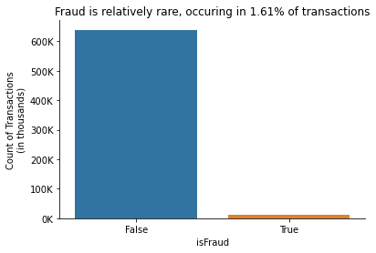

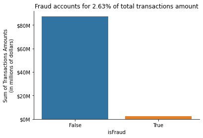

```python
# Evaluate frequency of fraud
sns.countplot(data=train_df,
              x='isFraud')
sns.despine()
_=plt.title('Fraud is relatively rare, occuring in {:.02%} of transactions'
          .format(train_df['isFraud'].mean()))

# Make axes more readable
plt.gca().get_yaxis().set_major_formatter(lambda x, p: '{:1.0f}K'.format(x/1e3))
plt.ylabel('Count of Transactions\n(in thousands)')

# Evaluate size of fraudulant transactions
plt.figure()
sns.barplot(data=train_df,
            x='isFraud',
            y='transactionAmount',
            estimator=sum,
            ci=None)

sns.despine()

# Make axes more readable and formated for dollars
plt.gca().get_yaxis().set_major_formatter(lambda x, p: '${:1.0f}M'.format(x/1e6))
plt.ylabel('Sum of Transactions Amounts\n(in millions of dollars)')


_=plt.title('Fraud accounts for {:.02%} of total transactions amount'
          .format(train_df[train_df['isFraud']==True]['transactionAmount'].sum()/train_df['transactionAmount'].sum()))
```

### Business impact

Applying the utility function detailed above to two dummy classifiers provides a baseline assessment of how fraud prediction could impact business results. The first dummy classifier never predicts fraud and the second always predicts fraud. The utility function is:

- Utility of un-identified fraud (false negative): -3.0 x (transaction amount)
- Utility of identifying fraud in error (false positive): -0.5 x (transaction amount)
- Utility of correctly identifying fraud (true positive): 0.5 x (transaction amount)
- Utility of correctly identifying normal transaction (true negative): 0.0

The dummy classifier used to always predict normal transaction is also baselined with the average precision score over the Precision-Recall (PR) Curve.

```python
"""
Create function to evaluate prediction utility and make into an scorer.
"""

# Create utility scorer
fraud_util = {
    'ufn':-3.0, # False Negative
    'ufp':-0.5, # False Positive
    'utp':0.5, # True Positive
    'utn':0.0, # True Negative
}

# All data used for ease of function call, this will not cause data leakage
# due to indexing of predictions
trans_amounts = df['transactionAmount']

def fraud_avg_utility_score(y_true, y_pred,):
    """
    Returns average utility score for predictions based on a defined utility
    function. Note that this function uses global variables for the fraud_util
    dictionary and the transaction amounts. This simplifies scorer calls for
    now and would updated in the future.

    Parameters:
    ___________
    y_true: pandas Series
        true values of the target
    y_pred: pandas Series
        predicted values of the target

    Returns:
    ________
    avg_utility: float
        average utility across observations

    """

    y_vals = y_true.values
    y_pred = np.array([y_pred]).reshape(-1,1)

    amounts = trans_amounts.loc[y_true.index]

    fn_mask = ((y_vals!=y_pred) & (y_vals==True))[:,0]
    fp_mask = ((y_vals!=y_pred) & (y_vals==False))[:,0]
    tp_mask = ((y_vals==y_pred) & (y_vals==True))[:,0]
    tn_mask = ((y_vals==y_pred) & (y_vals==False))[:,0]

    utility = 0
    utility += (amounts[fn_mask]*fraud_util['ufn']).values.sum()
    utility += (amounts[fp_mask]*fraud_util['ufp']).values.sum()
    utility += (amounts[tp_mask]*fraud_util['utp']).values.sum()
    utility += (amounts[tn_mask]*fraud_util['utn']).values.sum()

    avg_utility = utility/len(y_true)

    return avg_utility

def max_avg_utility_score(y_true, y_proba, return_avgs = False):
    util_scores = []
    thresholds = []
    for val in range(0,100,5):
        threshold = val/100
        y_pred = y_proba >= threshold
        avg_utility_threshold = fraud_avg_utility_score(y_true, y_pred)
        util_scores.append(avg_utility_threshold)
        thresholds.append(threshold)

    max_avg_util = max(util_scores)

    if return_avgs==False:
        return max_avg_util
    else:
        return max_avg_util, (util_scores, thresholds)



util_scorer = make_scorer(fraud_avg_utility_score, greater_is_better=True)
```

```python
def max_avg_utility_score(y_true, y_proba, return_avgs = False):
    """
    Calculates the maximum average utility for a range of classification
    thresholds. The results summarize the representative business value
    that could be provided by the model.

    Parameters:
    ___________
    y_true: pandas Series
        true values of the target
    y_proba: pandas Series
        predicted probability of each class
    return_avgs: bool
        indicates if the avg utility scores for each threshold should
        be returned

    Returns:
    ________
    max_avg_utility: float
        maximum average utility from tested thresholds
    util_scores: list
        average utility score from each theshold
    thresholds: list
        tested thresholds

    """

    util_scores = []
    thresholds = []
    for val in range(0,105,5):
        threshold = val/100
#         print(y_proba.shape[1])
#         if y_proba.shape[1]>1:
#             y_pred = (y_proba[:,1] >= threshold)
#         else:
#         print(y_proba)
#         print(threshold)
        y_pred = (y_proba>= threshold)
        avg_utility_threshold = fraud_avg_utility_score(y_true, y_pred)
        util_scores.append(avg_utility_threshold)
        thresholds.append(threshold)

    max_avg_util = max(util_scores)

    if return_avgs==False:
        return max_avg_util
    else:
        return max_avg_util, (util_scores, thresholds)


max_util_curve_scorer = make_scorer(max_avg_utility_score,
                                    greater_is_better=True,
                                    needs_proba=True,)
```

```python
from sklearn.dummy import DummyClassifier
"""
Creat dummy classifiers using scikit-learn.

"""

# Set features (X) and target (y)
X = train_df[['transactionAmount']] # column used for utility function
y = train_df[['isFraud']]
all_normal_clf = DummyClassifier(strategy='prior')
all_normal_clf.fit(X=X, y=y)
# Display results
display(all_normal_clf.predict(X=X)[0:5])
display(all_normal_clf.predict_proba(X=X)[0:5])


all_fraud_clf = DummyClassifier(strategy='constant', constant=True)
all_fraud_clf.fit(X=X, y=y)
# Display results
display(all_fraud_clf.predict(X=X)[0:5])
```

```
array([False, False, False, False, False])
```

```
array([[0.98394092, 0.01605908],
       [0.98394092, 0.01605908],
       [0.98394092, 0.01605908],
       [0.98394092, 0.01605908],
       [0.98394092, 0.01605908]])
```

```
array([ True,  True,  True,  True,  True])
```

```python
"""
Evaluate performance of dummy classifiers
"""

all_normal_clf = DummyClassifier(strategy='prior')
all_normal_clf.fit(X=X, y=y)

util_baseline_normal = max_util_curve_scorer(all_normal_clf, X, y)
util_baseline_fraud = max_util_curve_scorer(all_fraud_clf, X, y)

avg_pr_normal = average_precision_score(y,all_normal_clf.predict_proba(X)[:,1])
avg_pr_fraud = average_precision_score(y,all_fraud_clf.predict_proba(X)[:,1])


print("Always predicting normal transactions leads to an average utility of {:.01f} per transaction"
      .format(util_baseline_normal))

print("Always predicting normal transactions leads to an average precision of {:.03f}"
      .format(avg_pr_normal))

print("Always predicting fraudulent transactions leads to an average utility of {:.01f} per transaction"
      .format(util_baseline_fraud))

print("Always predicting fraudulent transactions leads to an average precision of {:.03f}"
      .format(avg_pr_fraud))
```

```
Always predicting normal transactions leads to an average utility of -10.9 per transaction
Always predicting normal transactions leads to an average precision of 0.016
Always predicting fraudulent transactions leads to an average utility of -65.5 per transaction
Always predicting fraudulent transactions leads to an average precision of 0.016
```

# Feature Development and Selection

The following cells explore the relationships between fraud and a series of existing and created features. The details for categorical and numerical features are described below. In summary, features that describe transactions, their verification, past fraud, and account status show statistical relationships to fraud. I note that the following features do not show a statistically significant relationship to fraud:

- Available money in the account ('availableMoney')
- Days until card expiration ('daysUntilExpiration')
- Day of the week ('dayWeek')
- Is a weekend ('isWeekEnd')
- Entered expiration date matches card expiration ('expirationDateKeyInMatch')
- Swipe following an initial multi-swipe ('subsequentEventChain')
- Swipe is the start of a multi-swipe ('originEventChain')

Visualizations and summary statistics are captured in the folder, Feature Evaluation.

## Review Features

```python
"""
Returning to the descriptive statistics in Question 1 to review features.
"""

def summarize_numeric_columns(df):
    """
    Generates summary statistics for numeric data.
    Numeric data are summarized with min, max, median, average, standard deviation, and missingness
    Assessment of unique/distinct values included to identify potential categorical features

    Parameters:
    ___________
    df : pandas dataframe
        The cleaned transaction dataframe

    Returns:
    ________
    num_summary: pandas dataframe
        Dataframe with summary statistics for each field
    """
    # Get numeric columns
    num_cols = df.select_dtypes(include = [np.number,bool]).columns #treating bool as [0,1]

    # Minimum
    num_summary = df[num_cols].min().to_frame()
    num_summary.columns = ['min']

    # Maximum
    num_summary = num_summary.join(
        df[num_cols].max().to_frame()
    )
    num_summary.rename(columns={0:'max'}, inplace=True)

    # Median
    num_summary = num_summary.join(
        df[num_cols].median().to_frame()
    )
    num_summary.rename(columns={0:'median'}, inplace=True)

    # Mean
    num_summary = num_summary.join(
        df[num_cols].mean().to_frame()
    )
    num_summary.rename(columns={0:'mean'}, inplace=True)

    # Mean
    num_summary = num_summary.join(
        df[num_cols].std().to_frame()
    )
    num_summary.rename(columns={0:'std'}, inplace=True)

    #Unique values to assess for categorical features
    num_summary = num_summary.join(
        df[num_cols].nunique().to_frame()
    )
    num_summary.rename(columns={0:'n_unique'}, inplace=True)

    # Unique values, showing values for when number of distinct values <=10
    # Cut-off based on the jump in distinct values from creditLimit (10) to cardCVV (899)
    unique_vals = pd.DataFrame(index=num_cols, columns=['unique values'])
    for nc in num_cols:
        if df[nc].nunique()<=10:
            unique_vals.loc[nc,'unique values'] = df[df[nc].notnull()][nc].unique()
        else:
            unique_vals.loc[nc,'unique values'] = 'many'

    num_summary = num_summary.join(unique_vals)

    # Missingness
    num_summary = num_summary.join(
        df.shape[0] - df[num_cols].count().to_frame()
    )
    num_summary.rename(columns={0:'count null'}, inplace=True)

    num_summary = num_summary.join(
        1 - df[num_cols].count().to_frame()/df.shape[0]
    )
    num_summary.rename(columns={0:'fraction null'}, inplace=True)

    return num_summary

def summarize_text_columns(df):
    """
    Generates summary statistics for text data (objects).
    Text data are summarized with a count and list of unique values as well as evaluation of missingness.

    Parameters:
    ___________
    df : pandas dataframe
        The cleaned transaction dataframe

    Returns:
    ________
    text_summary: pandas dataframe
        Dataframe with summary statistics for each text field
    """

    # Get text columns
    text_cols = df.select_dtypes(include = [object]).columns

    # Number of unique values
    text_summary = df[text_cols].nunique().to_frame()
    text_summary.columns = ['n_unique']

    # Missingness
    text_summary = text_summary.join(
        df.shape[0] - df[text_cols].count().to_frame()
    )
    text_summary.rename(columns={0:'count null'}, inplace=True)

    text_summary = text_summary.join(
        1 - df[text_cols].count().to_frame()/df.shape[0]
    )
    text_summary.rename(columns={0:'fraction null'}, inplace=True)

    # Unique values, showing values for when number of distinct values <20
    # Cut-off based on the jump in distinct values from merchantCategoryCode (10) to transactionAmount (66k)
    unique_vals = pd.DataFrame(index=text_cols, columns=['unique values'])
    for tc in text_cols:
        if df[tc].nunique()<20:
            unique_vals.loc[tc,'unique values'] = df[df[tc].notnull()][tc].unique()
        else:
            unique_vals.loc[tc,'unique values'] = 'many'

    text_summary = text_summary.join(unique_vals)

    return text_summary

def summarize_datetime_columns(df):
    """
    Generates summary statistics for datetime data.
    Datetime data are summarized with the minimum and maximum dates, unique dates, and missingness.

    Parameters:
    ___________
    df : pandas dataframe
        The cleaned transaction dataframe

    Returns:
    ________
    dt_summary: pandas dataframe
        Dataframe with summary statistics for each datetime field
    """
    # Get datetime columns
    dt_cols = df.select_dtypes(include = [np.datetime64]).columns

    # Minimum
    dt_summary = df[dt_cols].min().to_frame()
    dt_summary.columns = ['min']

    # Maximum
    dt_summary = dt_summary.join(
        df[dt_cols].max().to_frame()
    )
    dt_summary.rename(columns={0:'max'}, inplace=True)

    #Unique values to assess for categorical features
    dt_summary = dt_summary.join(
        df[dt_cols].nunique().to_frame()
    )
    dt_summary.rename(columns={0:'n_unique'}, inplace=True)

    # Missingness
    dt_summary = dt_summary.join(
        df.shape[0] - df[dt_cols].count().to_frame()
    )
    dt_summary.rename(columns={0:'count null'}, inplace=True)

    dt_summary = dt_summary.join(
        1- df[dt_cols].count().to_frame()/df.shape[0]
    )
    dt_summary.rename(columns={0:'fraction null'}, inplace=True)

    return dt_summary


# Assess field data types and missingness (null values)
# Note: initial inspection of the data showed no null values. Manually inspection of records suggested the empty strings were used to denote missing data
display(train_df.info())

#customized summary statistics for each field based on data type
num_summary = summarize_numeric_columns(train_df)
display(num_summary)

text_summary = summarize_text_columns(train_df)
display(text_summary)

dt_summary = summarize_datetime_columns(train_df)
display(dt_summary)

#Descriptive statistics for each field using built in pandas function, provides an alternative view of the summary statistics
with pd.option_context('display.max_columns', 29):
    display(df.describe(include='all', datetime_is_numeric=True))
```

```
<class 'pandas.core.frame.DataFrame'>
Int64Index: 649290 entries, 0 to 786340
Data columns (total 23 columns):
 #   Column                    Non-Null Count   Dtype
---  ------                    --------------   -----
 0   accountNumber             649290 non-null  object
 1   customerId                649290 non-null  object
 2   creditLimit               649290 non-null  int64
 3   availableMoney            649290 non-null  float64
 4   transactionDateTime       649290 non-null  datetime64[ns]
 5   transactionAmount         649290 non-null  float64
 6   merchantName              649290 non-null  object
 7   acqCountry                645493 non-null  object
 8   merchantCountryCode       648699 non-null  object
 9   posEntryMode              645951 non-null  object
 10  posConditionCode          648953 non-null  object
 11  merchantCategoryCode      649290 non-null  object
 12  currentExpDate            649290 non-null  datetime64[ns]
 13  accountOpenDate           649290 non-null  datetime64[ns]
 14  dateOfLastAddressChange   649290 non-null  datetime64[ns]
 15  cardCVV                   649290 non-null  object
 16  enteredCVV                649290 non-null  object
 17  cardLast4Digits           649290 non-null  object
 18  transactionType           648704 non-null  object
 19  currentBalance            649290 non-null  float64
 20  cardPresent               649290 non-null  bool
 21  expirationDateKeyInMatch  649290 non-null  bool
 22  isFraud                   649290 non-null  bool
dtypes: bool(3), datetime64[ns](4), float64(3), int64(1), object(12)
memory usage: 105.9+ MB
```

```
None
```

|  | min | max | median | mean | std | n_unique | unique values | count null | fraction null |
| --- | --- | --- | --- | --- | --- | --- | --- | --- | --- |
| creditLimit | 250 | 50000 | 7500.00 | 10767.735526 | 11646.691502 | 10 | [5000, 2500, 50000, 15000, 10000, 250, 500, 10... | 0 | 0.0 |
| availableMoney | -1005.63 | 50000.0 | 3219.68 | 6299.914404 | 8942.052733 | 453192 | many | 0 | 0.0 |
| transactionAmount | 0.0 | 2011.54 | 89.67 | 138.220522 | 148.132995 | 63311 | many | 0 | 0.0 |
| currentBalance | 0.0 | 47498.81 | 2409.80 | 4467.821122 | 6437.232385 | 424182 | many | 0 | 0.0 |
| cardPresent | False | True | 0.00 | 0.449322 | 0.497425 | 2 | [False, True] | 0 | 0.0 |
| expirationDateKeyInMatch | False | True | 0.00 | 0.001346 | 0.036664 | 2 | [False, True] | 0 | 0.0 |
| isFraud | False | True | 0.00 | 0.016059 | 0.125703 | 2 | [False, True] | 0 | 0.0 |

|  | n_unique | count null | fraction null | unique values |
| --- | --- | --- | --- | --- |
| accountNumber | 4976 | 0 | 0.000000 | many |
| customerId | 4976 | 0 | 0.000000 | many |
| merchantName | 2476 | 0 | 0.000000 | many |
| acqCountry | 4 | 3797 | 0.005848 | [US, CAN, MEX, PR] |
| merchantCountryCode | 4 | 591 | 0.000910 | [US, CAN, PR, MEX] |
| posEntryMode | 5 | 3339 | 0.005143 | [02, 09, 05, 80, 90] |
| posConditionCode | 3 | 337 | 0.000519 | [01, 08, 99] |
| merchantCategoryCode | 19 | 0 | 0.000000 | [rideshare, entertainment, fastfood, auto, onl... |
| cardCVV | 899 | 0 | 0.000000 | many |
| enteredCVV | 969 | 0 | 0.000000 | many |
| cardLast4Digits | 5213 | 0 | 0.000000 | many |
| transactionType | 3 | 586 | 0.000903 | [PURCHASE, ADDRESS_VERIFICATION, REVERSAL] |

|  | min | max | n_unique | count null | fraction null |
| --- | --- | --- | --- | --- | --- |
| transactionDateTime | 2016-01-01 00:01:02 | 2016-10-31 23:59:21 | 641313 | 0 | 0.0 |
| currentExpDate | 2019-12-01 00:00:00 | 2033-08-01 00:00:00 | 165 | 0 | 0.0 |
| accountOpenDate | 1989-08-22 00:00:00 | 2015-12-31 00:00:00 | 1819 | 0 | 0.0 |
| dateOfLastAddressChange | 1989-08-22 00:00:00 | 2016-10-31 00:00:00 | 2123 | 0 | 0.0 |

|  | accountNumber | customerId | creditLimit | availableMoney | transactionDateTime | transactionAmount | merchantName | acqCountry | merchantCountryCode | posEntryMode | posConditionCode | merchantCategoryCode | currentExpDate | accountOpenDate | dateOfLastAddressChange | cardCVV | enteredCVV | cardLast4Digits | transactionType | currentBalance | cardPresent | expirationDateKeyInMatch | isFraud |
| --- | --- | --- | --- | --- | --- | --- | --- | --- | --- | --- | --- | --- | --- | --- | --- | --- | --- | --- | --- | --- | --- | --- | --- |
| count | 786363 | 786363 | 786363.000000 | 786363.000000 | 786363 | 786363.000000 | 786363 | 781801 | 785639 | 782309 | 785954 | 786363 | 786363 | 786363 | 786363 | 786363 | 786363 | 786363 | 785665 | 786363.000000 | 786363 | 786363 | 786363 |
| unique | 5000 | 5000 | NaN | NaN | NaN | NaN | 2490 | 4 | 4 | 5 | 3 | 19 | NaN | NaN | NaN | 899 | 976 | 5245 | 3 | NaN | 2 | 2 | 2 |
| top | 380680241 | 380680241 | NaN | NaN | NaN | NaN | Uber | US | US | 05 | 01 | online_retail | NaN | NaN | NaN | 869 | 869 | 593 | PURCHASE | NaN | False | False | False |
| freq | 32850 | 32850 | NaN | NaN | NaN | NaN | 25613 | 774709 | 778511 | 315035 | 628787 | 202156 | NaN | NaN | NaN | 33749 | 33424 | 32946 | 745193 | NaN | 433495 | 785320 | 773946 |
| mean | NaN | NaN | 10759.464459 | 6250.725369 | 2016-07-06 01:58:58.395681536 | 136.985791 | NaN | NaN | NaN | NaN | NaN | NaN | 2026-09-25 23:50:42.724542720 | 2014-02-03 01:11:17.352825856 | 2015-04-14 06:46:41.127723520 | NaN | NaN | NaN | NaN | 4508.739089 | NaN | NaN | NaN |
| min | NaN | NaN | 250.000000 | -1005.630000 | 2016-01-01 00:01:02 | 0.000000 | NaN | NaN | NaN | NaN | NaN | NaN | 2019-12-01 00:00:00 | 1989-08-22 00:00:00 | 1989-08-22 00:00:00 | NaN | NaN | NaN | NaN | 0.000000 | NaN | NaN | NaN |
| 25% | NaN | NaN | 5000.000000 | 1077.420000 | 2016-04-06 19:35:07 | 33.650000 | NaN | NaN | NaN | NaN | NaN | NaN | 2023-05-01 00:00:00 | 2013-06-29 00:00:00 | 2014-10-08 00:00:00 | NaN | NaN | NaN | NaN | 689.910000 | NaN | NaN | NaN |
| 50% | NaN | NaN | 7500.000000 | 3184.860000 | 2016-07-08 05:03:57 | 87.900000 | NaN | NaN | NaN | NaN | NaN | NaN | 2026-10-01 00:00:00 | 2014-09-05 00:00:00 | 2016-01-13 00:00:00 | NaN | NaN | NaN | NaN | 2451.760000 | NaN | NaN | NaN |
| 75% | NaN | NaN | 15000.000000 | 7500.000000 | 2016-10-05 13:52:03.500000 | 191.480000 | NaN | NaN | NaN | NaN | NaN | NaN | 2030-03-01 00:00:00 | 2015-05-04 00:00:00 | 2016-06-06 00:00:00 | NaN | NaN | NaN | NaN | 5291.095000 | NaN | NaN | NaN |
| max | NaN | NaN | 50000.000000 | 50000.000000 | 2016-12-30 23:59:45 | 2011.540000 | NaN | NaN | NaN | NaN | NaN | NaN | 2033-08-01 00:00:00 | 2015-12-31 00:00:00 | 2016-12-30 00:00:00 | NaN | NaN | NaN | NaN | 47498.810000 | NaN | NaN | NaN |
| std | NaN | NaN | 11636.174890 | 8880.783989 | NaN | 147.725569 | NaN | NaN | NaN | NaN | NaN | NaN | NaN | NaN | NaN | NaN | NaN | NaN | NaN | 6457.442068 | NaN | NaN | NaN |

## Assess categorical features

I noticed above that categorical and boolean features fall into three groups: 1) transaction desciptors, 2) unique identifiers, and 3) verifications. While it may be possible, even useful, to build models for individual accounts or include the unique identifiers are features, I chose not to look at unique identifier at this point and instead focus on transaction descriptors and verfications. With the limited time available, I opt to create and futures that describe relevant behaviors across customers. These features include past fraudulent activites, multi-swipe or chain transactions, and missed verification checks.

The resulting combination of created and existing features are visually and statistically inspected using a chi-squared contingency table test. The results suggest that most categorical features have statistically meaningful correlations with the probability of fraud. Some key observations:

- Previous fraud for a card, merchant-customer pair, or company-customer pair appears to be a good discrimnator.
- Matching CVV codes is associated with a lower probability of fraud, but matching expiration dates are not strongly associated with differences in fraud.
- Multi-swipes do not have as strong correlations with fraud.
- The day of the week does not have a strong correlation with fraud. However mid-day shows a slightly increased frequency of fraud.
- Some transactions types and point-of-sale conditions codes and entry modes are more likely to experience fraud than others.
- Fraud seems more frequent in transactions involving Canada and Mexico than transactions in the United States or Puerto Rico.
- Due to the cardinality of the merchant category, I chose to use the created company category, which has lower cardinality and shows a statistical association with the frequency of fraud.

```python
def create_categorical_features(df):
    """
    Function to generate desired categorical features

    Parameters:
    ___________
    df: pandas dataframe
        transaction dataset

    Returns:
    ________
    df: pandas dataframe
        transaction dataset augmented with additional features
    cat_feats: list
        names of categorical features
    """

    # Existing transaction descriptors
    transaction_desc_feats = [c for c in df.select_dtypes(include = [object]).columns if df[c].nunique()<20]

    """
    Inspecting merchants suggests that brick-and-mortar merchants have
    individual stores listed. I summarize those merchants into companies
    for inspection.
    """

    df['companyName'] = (df['merchantName']
                         .str.split('#')
                         .str[0]
                         .str.strip())

    transaction_desc_feats.append('companyName')
    transaction_desc_feats.append('merchantName')

    #Day of week, weekend, and time of day
    df['dayWeek'] = df['transactionDateTime'].dt.day_name()
    df['isWeekEnd'] = df['dayWeek'].isin(['Saturday','Sunday'])
    df['hour24'] = df['transactionDateTime'].dt.hour

    transaction_desc_feats += ['dayWeek','isWeekEnd','hour24']

    # Existing verification features
    verification_feats = ['cardPresent','expirationDateKeyInMatch','creditLimit']

    # Create features for verifications
    # Matched CVV
    df['matchedCVV'] = df['enteredCVV']==df['cardCVV']
    verification_feats.append('matchedCVV')

    # Overdrawn account
    df['overDraw'] = df['transactionAmount'] > df['availableMoney']
    verification_feats.append('overDraw')

    # Multi-swipe features
    df, multi_swipe_feats = create_multi_swipe_features(df)
    verification_feats+=multi_swipe_feats

    # Previous Fraud
    # Note that these features are backward looking and assume all previous
    # transaction data are available.

    # Order transaction data
    df = df.sort_values('transactionDateTime')

    # Create previous fraud feature list
    previous_fraud_feats = []

    # Has this card been used previously for fraud
    keep_cols = ['customerId','cardLast4Digits','transactionDateTime','isFraud']

    # Self-join using merge_asof to identify any preceding fraudulent transaction
    # that matches the customer and the card
    df = pd.merge_asof(df, df[keep_cols],
                             on='transactionDateTime',
                             by=['customerId','cardLast4Digits'],
                             suffixes=("","_previousCard"),
                             allow_exact_matches = False)

    #Fill in censored data
    df['isFraud_previousCard'].fillna(False, inplace=True)

    previous_fraud_feats.append('isFraud_previousCard')

    # Has this customer-merchant pair been used previously for fraud
    keep_cols = ['customerId', 'merchantName', 'transactionDateTime', 'isFraud']

    # Self-join using merge_asof to identify any preceding fraudulent transaction
    # that matches the customer and the card
    df = pd.merge_asof(df, df[keep_cols],
                       on='transactionDateTime',
                       by=['customerId','merchantName'],
                       suffixes=("","_previousMerchant"),
                       allow_exact_matches = False)

    #Fill in censored data
    df['isFraud_previousMerchant'].fillna(False, inplace=True)

    previous_fraud_feats.append('isFraud_previousMerchant')

    # Has this customer-company pair been used previously for fraud
    keep_cols = ['customerId', 'companyName', 'transactionDateTime', 'isFraud']

    # Self-join using merge_asof to identify any preceding fraudulent transaction
    # that matches the customer and the card
    df = pd.merge_asof(df, df[keep_cols],
                             on='transactionDateTime',
                             by=['customerId','companyName'],
                             suffixes=("","_previousCompany"),
                             allow_exact_matches = False)

    #Fill in censored data
    df['isFraud_previousCompany'].fillna(False, inplace=True)

    previous_fraud_feats.append('isFraud_previousCompany')

    return df, transaction_desc_feats+verification_feats+previous_fraud_feats

def create_multi_swipe_features(df):
    """
    Function to generate features describing multi-swipes. Note that
    all features are backwards looking as to not create data leakage
    that would invalidate model testing. This assumes that all previous
    transaction data is available at time of prediction.

    Parameters:
    ___________
    df: pandas dataframe
        transaction dataset

    Returns:
    ________
    multi_df: pandas dataframe
        transaction dataset augmented with additional features
    multi_feats: list
        names of categorical features
    """

    # Create unique id for each transaction
    df['transactionId'] = df.index.astype(str)

    # Order transaction data
    df = df.sort_values('transactionDateTime')

    # Set columns that will be used for merging later on
    keep_cols = ['customerId','merchantName','transactionDateTime','transactionAmount','transactionId']

    # Parameterize the time window
    minutes_window = 10

    # Self-join using merge_asof to identify any preceding transaction within the
    # specified time-window that matches the customer, merchant, and transaction amount.
    multi_df = pd.merge_asof(df, df[keep_cols],
                             on='transactionDateTime',
                             by=['customerId', 'transactionAmount','merchantName'],
                             suffixes=("","_previous"),
                             tolerance = pd.Timedelta(minutes=minutes_window),
                             allow_exact_matches = False)


    # The dataframe produced above identifies the previous multi-swipe or reversal
    # transaction in the "transactionId_previous" field.
    # I am interested in identfying the transaction that started the multi-swipe/reversal event chain
    # The starting transaction will be referenced in other records as a previous transaction,
    # but will not have a predecessor. This makes it relative easy to identify.
    multi_start_df = multi_df[
        (multi_df['transactionId'].isin(multi_df['transactionId_previous'])) &
        (multi_df['transactionId_previous'].isnull())]

    multi_start_df['transactionIdEventChainStart'] = multi_start_df['transactionId']

    # Re-joining the resulting transactionIdEventChainStart field to the previous records
    # identified as multi-swipe establishes which multi-swipe/reversals are associated with each event chain
    # No tolerance is used, because a chain of swipes and reversals could theoretically go longer
    # than the individual event window.
    keep_cols = ['customerId','merchantName','transactionDateTime','transactionAmount','transactionIdEventChainStart']


    multi_df = pd.merge_asof(multi_df,
                             multi_start_df[keep_cols],
                             on='transactionDateTime',
                             by=['customerId', 'transactionAmount','merchantName'],
                             allow_exact_matches = True) #allow exact matches so the start of the chain is identfied

    # Clean up matches outside of an event chain
    multi_df.loc[(multi_df['transactionId_previous'].isnull()) &
                 (multi_df['transactionId']!=multi_df['transactionIdEventChainStart']),
                 'transactionIdEventChainStart'] = np.nan

    # Create inidicator variables for future use
    # Indicate transaction in event chain
    multi_df.loc[:,'inEventChain'] = 0
    multi_df.loc[multi_df['transactionIdEventChainStart'].notnull(),
                'inEventChain'] = 1

    # Indicate origin of event chain, the first swipe
    multi_df.loc[:,'originEventChain'] = 0
    multi_df.loc[multi_df['transactionId']==multi_df['transactionIdEventChainStart'],
                'originEventChain'] = 1

    # Indicate subsequent activity in event chain
    multi_df.loc[:,'subsequentEventChain'] = 0
    multi_df.loc[(multi_df['transactionId']!=multi_df['transactionIdEventChainStart']) &
                 (multi_df['inEventChain']==1),
                'subsequentEventChain'] = 1

    multi_feats = ['inEventChain','originEventChain','subsequentEventChain']

    return multi_df, multi_feats
```

```python
# Create desired categoricals
train_df_feats, cat_feats = create_categorical_features(train_df)
```

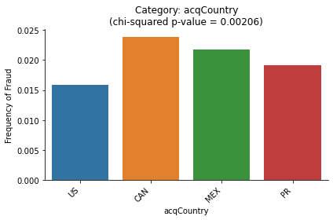

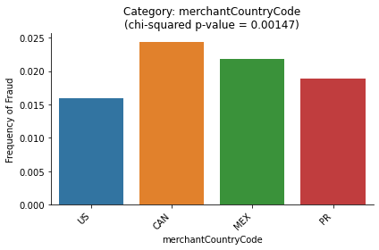

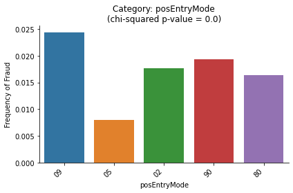

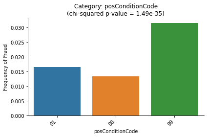

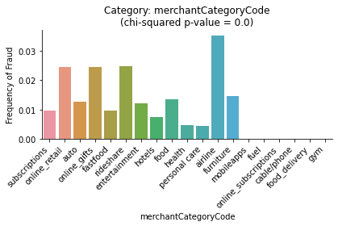

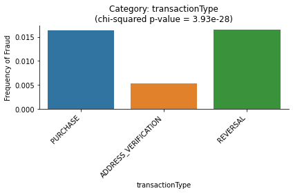

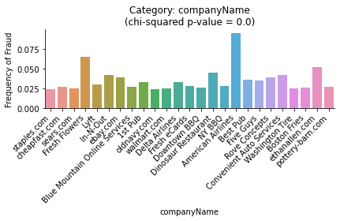

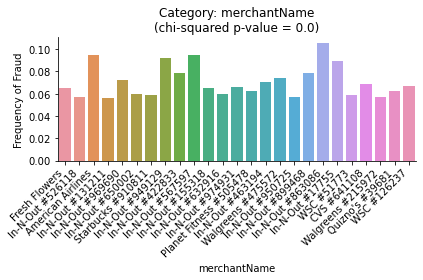

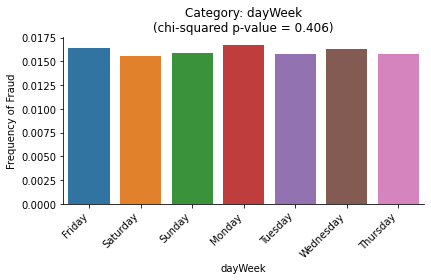

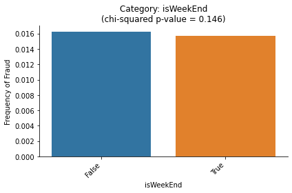

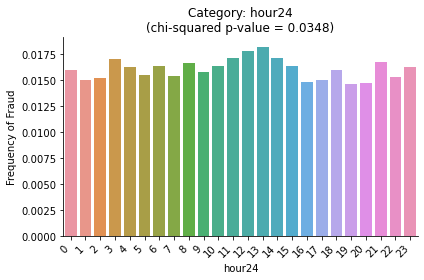

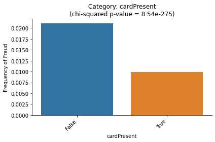

[10 more figures not shown]

```python
# Visually and statistically (chi-squared contingency table)
# inspect fraud frequency
for c in cat_feats:
    # Check chi-squared statistic for each feature and fraud
    tab = (train_df_feats.groupby([c,'isFraud'])[['customerId']]
           .count()
           .unstack()
           .fillna(0))

    chi2_stat, p_val, dof, expected = chi2_contingency(tab.to_numpy())

    # Plot
    if train_df_feats[c].nunique()<25:
        plt.figure()
        sns.barplot(data = train_df_feats,
                   y='isFraud',
                   x=c,
                   ci=None)

    # Plot many categories, just the top 20
    else:
        inspect = (train_df_feats.groupby(c)[['isFraud']]
                   .mean()
                   .sort_values('isFraud',ascending=False)
                   .iloc[0:25]
                   .index)

        plt.figure()
        sns.barplot(data = train_df_feats[train_df_feats[c].isin(inspect)],
                   y='isFraud',
                   x=c,
                   ci=None)

    plt.xticks(rotation=45,ha='right')
    sns.despine()
    plt.title('Category: {}\n(chi-squared p-value = {:.03})'.format(c, p_val))
    plt.ylabel('Frequency of Fraud')
    plt.tight_layout()
    plt.savefig('Feature Evaluation/{}.png'.format(c))
```

### Create Numeric Features

Reviewing the existing numeric features indicate that distributions of transaction amount and current balance are different between fraudulent and normal transactions (statistical tests reject the null hypothesis that the sample observations are drawn from the same distribution, or have the same mean). The distributions of available money are not statistically different. I also create features for:

- fraction of credit limit used by the transaction
- fraction of credit currently utilized
- account age, days since address change
- days until card expiration
- hours since last transaction

The data suggests that all, execpt for days until card expiration, have different distributions in fraudulent transactions.

```python
def create_numeric_features(df):

    # Existing numeric features
    account_feats = ['availableMoney','transactionAmount','currentBalance']

    df['fractionCreditLimit'] = df['transactionAmount'] / df['creditLimit'].astype(float)
    df['fractionCreditUtilization'] = df['currentBalance'] / df['creditLimit'].astype(float)


    # Features based on time differences
    # Order transaction data
    df = df.sort_values('transactionDateTime')

    # Create a few self-explanator features
    df['accountAge'] = (df['transactionDateTime'] - df['accountOpenDate']).dt.days
    df['daysSinceAddressChange'] = (df['transactionDateTime'] - df['dateOfLastAddressChange']).dt.days
    df['daysUntilExpiration'] = (df['currentExpDate'] - df['transactionDateTime']).dt.days

    # Shift the previous transaction up for comparison
    df['lastTransaction'] = df.groupby('customerId')['transactionDateTime'].shift()
    df['hoursSinceLastTransaction'] = (df['transactionDateTime'] - df['lastTransaction']) / pd.Timedelta(hours=1)

    time_feats = ['accountAge','daysSinceAddressChange','daysUntilExpiration',
                  'fractionCreditLimit','fractionCreditUtilization',
                  'hoursSinceLastTransaction',
                 ]

    num_feats = account_feats+time_feats

    return df, num_feats
```

```python
# Create desired numeric features
train_df_feats, num_feats = create_numeric_features(train_df)
```

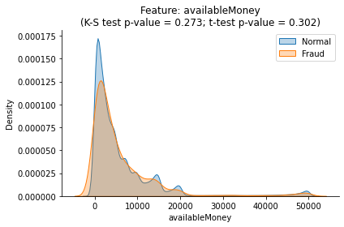

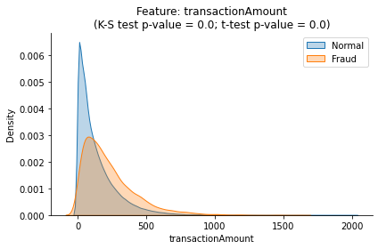

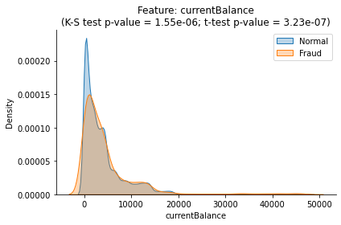

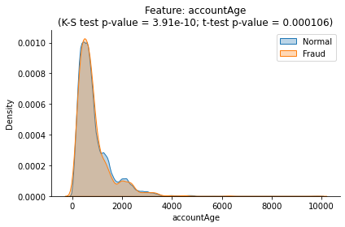

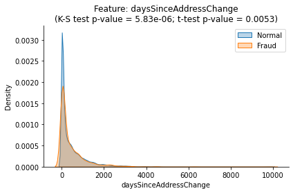

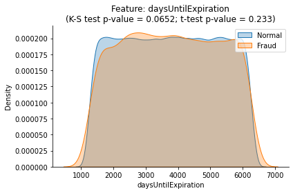

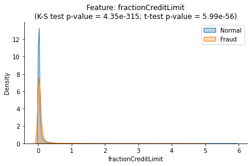

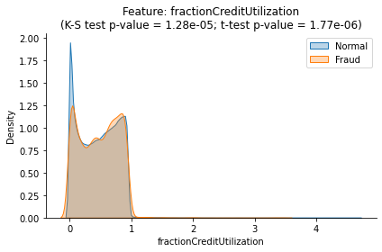

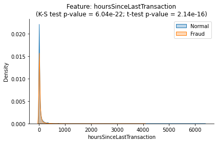

```python
# Visually and statistically (two-sided Kolmogorov-Smirnov test and t test)
# inspect distributions of normal and fraudulent data
for c in num_feats:
    plt.figure()
    sns.kdeplot(
        data=train_df_feats[train_df_feats['isFraud']==False],
        x=c,
        label='Normal',
        fill=True,
        alpha=0.3
    )

    sns.kdeplot(
            data=train_df_feats[train_df_feats['isFraud']==True],
            x=c,
            label='Fraud',
            fill=True,
            alpha=0.3
        )

    plt.legend()
    sns.despine()

    ks_stat, ksp_val = stats.ks_2samp(
        train_df_feats[train_df_feats['isFraud']==False][c].dropna(),
        train_df_feats[train_df_feats['isFraud']==True][c].dropna()
    )

    t_stat, tp_val = stats.ttest_ind(
        train_df_feats[train_df_feats['isFraud']==False][c].dropna(),
        train_df_feats[train_df_feats['isFraud']==True][c].dropna()
    )

    plt.title('Feature: {}\n(K-S test p-value = {:.03}; t-test p-value = {:.03})'.format(c, ksp_val,tp_val))
    plt.tight_layout()
    plt.savefig('Feature Evaluation/{}.png'.format(c))
```

# Model Development

The following cells test Logistic Regression and Random Forest models on the fraud prediction task. These cells leverage the evaluation criteria and the features developed above. Model training and testing is limited due to the computational power of my personal computer, so I chose to keep the models and hyper-parameter tuning relatively simple.

Reviewing the confusion matrix for the holdout predictions shows a balance between false positive and false negatives. These errors would be further investigated to understand what types of observations were being mis-classified.

Notes on my approach are below:

- Models were chosen to be representative of different classifier types: linear models and random forests.
- There are many potential extensions to these models including creating more complex models, increasing their size, improving hyper-parameter tuning, adding automated feature selection, and exploring neural networks and other modeling types. These are detailed in the notebook summary above.
- Although I was not able to run additional models and hyper-parameter tuning, I provide examples of code I would have used. I also include code to run a Support Vector Classifier, which would have provided another type of classifier for consideration.
- Models are trained with class weights based on the frequency of fraud in the data. This is itended to help the model perform better on the positive class, but could be more thoroughly tested in the future.

```python
"""
Load training data and establish features of interest based on
the above results. Note that I chose to process the full dataset to
create the features established above and then re-create the hold-out set.
This is done for simplicity due to limited time. Each created feature is
designed to be backward looking, so this step does not create data leakage.

In production, the feature creation steps would be pipelined so that new
data could be created as it is collected.
"""

df_raw = get_transaction_data()
df = clean_transation_data(df_raw)
df = df.sort_values('transactionDateTime')

# Process full dataset and then re-split training and holdout
df_feats, cat_feats = create_categorical_features(df)
df_feats, num_feats = create_numeric_features(df_feats)

# Re-establish holdout and training
hold_df_feats = df_feats[df_feats['transactionDateTime']>='2016-11-01']
train_df_feats = df_feats[df_feats['transactionDateTime']<'2016-11-01']

# Drop features that were not strongly associated with fraud
skip_feats = ['availableMoney','daysUntilExpiration',
              'dayWeek','isWeekEnd',
              'expirationDateKeyInMatch',
              'subsequentEventChain',
              'originEventChain',
              'merchantName' # dropped in favor of companyName due to cardinality
             ]

cat_feats = [c for c in cat_feats if c not in skip_feats]
num_feats = [c for c in num_feats if c not in skip_feats]
```

```python
"""
First create custom cross validation (cv) function used as the outer cv
iterator to evaluate performance on test sets. This is necessary due to
limitations in the built-in scikit-learn TimeSeriesSplit functionality.
Second, create stratified k-fold cv for model tuning within time series
cv splits as needed.
"""
rand_state = 42

def time_series_split(df, n_splits=5, date_col='transactionDateTime'):
    """
    Creates a walk-forward cross-validation iterator for testing how
    models trained on previous days will perform on future days.

    Parameters:
    ___________
    df: pandas dataframe
        dataset
    n_splits: int
        number of splits
    date_col: str
        name of datetime column used for splitting

    Returns:
    ________
    ts_split: list
        list of (train, test) splits as indices
    """

    total_days = (df[date_col].dt.date.max() - df[date_col].dt.date.min()).days
    split_days = total_days/(n_splits+1)

    ts_split = []
    train_start_date = df[date_col].dt.date.min()
    for i in range(0,n_splits):
        train_end_date = train_start_date+pd.Timedelta(days=split_days*(i+1))
        test_start_date = train_start_date+pd.Timedelta(days=split_days*(i+1))
        test_end_date = test_start_date+pd.Timedelta(days=split_days)
#         print('train: {} - {}'.format(train_start_date,train_end_date))
#         print('test: {} - {}'.format(test_start_date,test_end_date))
        train_ix = df[(df[date_col]>=pd.to_datetime(train_start_date)) &
                        (df[date_col]<=pd.to_datetime(train_end_date))].index
        test_ix = df[(df[date_col]>=pd.to_datetime(test_start_date)) &
                     (df[date_col]<=pd.to_datetime(test_end_date))].index

        ts_split.append((train_ix,test_ix))

        #Check for overlapping indices
        if len(set(train_ix).intersection(set(test_ix)))>0:
            print('Warning: Overlapping indices')

    return ts_split

tscv = time_series_split(train_df_feats)
skf = StratifiedKFold(n_splits=5, random_state=rand_state)
```

```python
"""
Define preprocessing pipeline using scikit-learn pipelines. Modifying a
useful demonstration from sci-kit learn documentation:
https://scikit-learn.org/stable/auto_examples/compose/plot_column_transformer_mixed_types.html
"""

numeric_transformer = Pipeline(
    steps=[("imputer", SimpleImputer(strategy="median")),
           ("scaler", StandardScaler())]
)

categorical_transformer = Pipeline(
    steps=[("imputer", SimpleImputer(strategy="constant",fill_value='Missing')),
           ("encoder", OneHotEncoder(handle_unknown="ignore"))]
)

preprocessor = ColumnTransformer(
    transformers=[
        ("num", numeric_transformer, num_feats),
        ("cat", categorical_transformer, cat_feats),
    ]
)
```

### Demonstration of evaluation and modeling

```
The best model had Average Precision = 0.129, compared to the baseline 0.0161
```

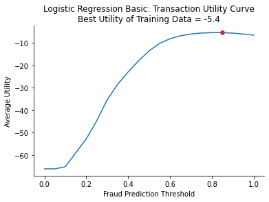

```python
"""
Demonstrate training and scoring a modeling using the steps above.
"""
from sklearn.linear_model import LogisticRegressionCV

clf = LogisticRegressionCV(
    Cs=1,
    cv=tscv,
    penalty='l2',
    class_weight='balanced',
    refit=True,
    random_state=rand_state,
    scoring='average_precision'
)

pipe = Pipeline(
    steps=[
        ('preproc',preprocessor),
        ('clf', clf)
    ]
)

# Fit Demonstration Model:
pipe.fit(train_df_feats[num_feats+cat_feats],train_df_feats['isFraud'])

# Evaluate Score
best_score_ap = np.max(np.mean(pipe.named_steps['clf'].scores_[True],axis=0))

print('The best model had Average Precision = {:.03}, compared to the baseline {:.03}'
      .format(best_score_ap,avg_pr_normal))

max_util, (util_scores, thresholds) = max_avg_utility_score(y_true=train_df_feats[['isFraud']],
                      y_proba = pipe.predict_proba(X=train_df_feats[num_feats+cat_feats])[:,1],
                      return_avgs=True)

best_util_ix = np.argmax(util_scores)
plt.plot(thresholds, util_scores, label='Utility Curve')
plt.scatter(thresholds[best_util_ix],
            util_scores[best_util_ix],
            s=30,
            c='r',
           label='Best Utility Score')

sns.despine()
plt.ylabel('Average Utility')
plt.xlabel('Fraud Prediction Threshold')
_=plt.title('Logistic Regression Basic: Transaction Utility Curve\nBest Utility of Training Data = {:.02}'.format(util_scores[best_util_ix]))
```

### Logistic Regression Model

```python
"""
Use a similar model as above, but include cross-validation and
hyper-parameter tuning with built-in functionality.
"""

clf = LogisticRegressionCV(
    Cs=5,
    cv=skf,
    penalty='l2',
    class_weight='balanced',
    refit=True,
    random_state=rand_state,
    scoring='average_precision'
)

pipe = Pipeline(
    steps=[
        ('preproc',preprocessor),
        ('clf', clf)
    ]
)

# Create manual cross validation loop to test utility maximization
max_utils = []
avg_precs = []
scores_thresholds = []

for i,(train_ix,test_ix) in enumerate(tscv):
    # Train
    pipe.fit(train_df_feats[num_feats+cat_feats].iloc[train_ix],
             train_df_feats['isFraud'].iloc[train_ix])
    # Test
    y_true = train_df_feats[['isFraud']].iloc[test_ix]
    y_proba = pipe.predict_proba(X=train_df_feats[num_feats+cat_feats].iloc[test_ix])[:,1]

    max_util, (util_scores, thresholds) = max_avg_utility_score(y_true=y_true,
                      y_proba = y_proba,
                      return_avgs=True)

    max_utils.append(max_util)
    scores_thresholds.append((util_scores, thresholds))
    avg_precs.append(average_precision_score(y_true,y_proba))
    print('Fold {}: max util = {:.03}, average precision = {:.03}'
         .format(i,max_util,average_precision_score(y_true,y_proba)))
```

```
Fold 0: max util = -5.22, average precision = 0.161
Fold 1: max util = -5.22, average precision = 0.167
Fold 2: max util = -4.87, average precision = 0.169
Fold 3: max util = -4.51, average precision = 0.185
Fold 4: max util = -4.31, average precision = 0.188
```

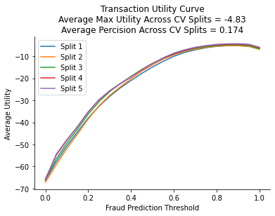

```python
for i, (util_scores,thresholds) in enumerate(scores_thresholds) :
    plt.plot(thresholds, util_scores, label='Split {}'.format(i+1))

sns.despine()
plt.ylabel('Average Utility')
plt.xlabel('Fraud Prediction Threshold')
_=plt.title('Transaction Utility Curve\nAverage Max Utility Across CV Splits = {:.03}\nAverage Percision Across CV Splits = {:.03}'
            .format(np.mean(max_utils),np.mean(avg_precs)))
plt.legend()
```

### Random Forest

```python
"""
Test Random Forest with adjustment to default. Code for a basic
gridsearch hyper-parameter tuning is left in the cell as an example of
nexts steps.
"""

"""
parameters = {'n_estimator':[100,1000,5000],
              'max_samples':[0.1, 0.4, 0.7, None],
             'class_weight':['balanced','balanced_subsample',None]}

clf = GridSearchCV(
    estimator=RandomForestClassifier(),
    cv=skf,
    param_grid=parameters,
    refit=True,
    scoring='average_precision',
    verbose=2
)

pipe = Pipeline(
    steps=[
        ('preproc',preprocessor),
        ('clf', clf)
    ]
)
"""

rf_clf = RandomForestClassifier(
    class_weight='balanced',
)

rf_pipe = Pipeline(
    steps=[
        ('preproc',preprocessor),
        ('clf', rf_clf)
    ]
)

# Create manual cross validation loop to test utility maximization

rf_max_utils = []
rf_avg_precs = []
rf_scores_thresholds = []

for i, (train_ix,test_ix) in enumerate(tscv):
    # Train
    rf_pipe.fit(train_df_feats[num_feats+cat_feats].iloc[train_ix],
             train_df_feats['isFraud'].iloc[train_ix])
    # Test
    y_true = train_df_feats[['isFraud']].iloc[test_ix]
    y_proba = rf_pipe.predict_proba(X=train_df_feats[num_feats+cat_feats].iloc[test_ix])[:,1]

    max_util, (util_scores, thresholds) = max_avg_utility_score(y_true=y_true,
                      y_proba = y_proba,
                      return_avgs=True)

    rf_max_utils.append(max_util)
    rf_scores_thresholds.append((util_scores, thresholds))
    rf_avg_precs.append(average_precision_score(y_true,y_proba))
    print('Fold {}: max util = {:.03}, average precision = {:.03}'
         .format(i,max_util,average_precision_score(y_true,y_proba)))
```

```
Fold 0: max util = -4.91, average precision = 0.281
Fold 1: max util = -5.05, average precision = 0.307
Fold 2: max util = -4.61, average precision = 0.324
Fold 3: max util = -4.24, average precision = 0.341
Fold 4: max util = -4.04, average precision = 0.357
```

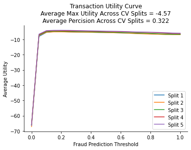

```python
for i, (util_scores,thresholds) in enumerate(rf_scores_thresholds) :
    plt.plot(thresholds, util_scores, label='Split {}'.format(i+1))

sns.despine()
plt.ylabel('Average Utility')
plt.xlabel('Fraud Prediction Threshold')
_=plt.title('Transaction Utility Curve\nAverage Max Utility Across CV Splits = {:.03}\nAverage Percision Across CV Splits = {:.03}'
            .format(np.mean(rf_max_utils),np.mean(rf_avg_precs)))
plt.legend()
```

### Support Vector Machine - Example Not Executed

```python
"""
Prepar Support Vector Classifier with default parameters. I was not
able to run this model in the time available so the code is left below
for review. I also include code for a basic gridsearch hyper-parameter
tuning is left in the cell as an example of nexts steps.
"""

"""
parameters = {'kernel':('linear', 'rbf'),
              'C':[0.1, 1, 10, 100],
             'class_weight':['balanced',None]}

clf = GridSearchCV(
    estimator=SVC(
        probability=True
    ),
    cv=skf,
    param_grid=parameters,
    refit=True,
    scoring='average_precision',
    verbose=2
)

pipe = Pipeline(
    steps=[
        ('preproc',preprocessor),
        ('clf', clf)
    ]
)
"""

svc_clf = SVC(
    class_weight='balanced',
    kernel='rbf',
    probability=True
)

svc_pipe = Pipeline(
    steps=[
        ('preproc',preprocessor),
        ('clf', svc_clf)
    ]
)

# Create manual cross validation loop to test utility maximization

svc_max_utils = []
svc_avg_precs = []
svc_scores_thresholds = []

for i, (train_ix,test_ix) in enumerate(tscv):
    # Train
    svc_pipe.fit(train_df_feats[num_feats+cat_feats].iloc[train_ix],
             train_df_feats['isFraud'].iloc[train_ix])
    # Test
    y_true = train_df_feats[['isFraud']].iloc[test_ix]
    y_proba = svc_pipe.predict_proba(X=train_df_feats[num_feats+cat_feats].iloc[test_ix])[:,1]

    max_util, (util_scores, thresholds) = max_avg_utility_score(y_true=y_true,
                      y_proba = y_proba,
                      return_avgs=True)

    svc_max_utils.append(max_util)
    svc_scores_thresholds.append((util_scores, thresholds))
    svc_avg_precs.append(average_precision_score(y_true,y_proba))
    print('Fold {}: max util = {:.03}, average precision = {:.03}'
         .format(i,max_util,average_precision_score(y_true,y_proba)))
```

```python
for i, (util_scores,thresholds) in enumerate(svc_scores_thresholds) :
    plt.plot(thresholds, util_scores, label='Split {}'.format(i+1))

sns.despine()
plt.ylabel('Average Utility')
plt.xlabel('Fraud Prediction Threshold')
_=plt.title('Transaction Utility Curve\nAverage Max Utility Across CV Splits = {:.03}\nAverage Percision Across CV Splits = {:.03}'
            .format(np.mean(svc_max_utils),np.mean(svc_avg_percs)))
plt.legend()
```

### Evaluation on holdout data

```python
"""
This step uses the best model, Random Forest, on the holdout data to
evaluate model performance in a setting with truly unseen data.

"""
X_train = train_df_feats[num_feats+cat_feats]
y_train = train_df_feats[['isFraud']]

X_test = hold_df_feats[num_feats+cat_feats]
y_test = hold_df_feats[['isFraud']]

rf_clf = RandomForestClassifier(
    class_weight='balanced',
)

rf_pipe_final = Pipeline(
    steps=[
        ('preproc',preprocessor),
        ('clf', rf_clf)
    ]
)


# Fit to training data
print('Fit')
rf_pipe_final.fit(X_train, y_train)

# Predict test data
print('Predict')
y_proba = rf_pipe_final.predict_proba(X_test)
```

```
Fit
Predict
```

```
Baseline Performance: Utilty Score = -5.8, Averag PR = 0.0145
```

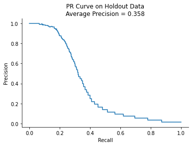

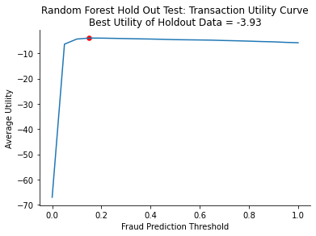

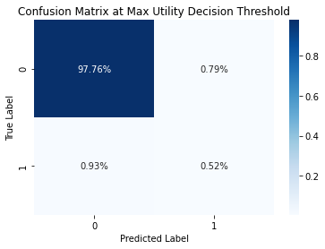

```python
# Evaluate performance
# Create dummy classifier for comparison
# Set features (X) and target (y)
all_normal_clf = DummyClassifier(strategy='prior')
all_normal_clf.fit(X=X_train, y=y_train)

util_baseline = max_util_curve_scorer(all_normal_clf, X_test, y_test)
avg_pr_baseline = average_precision_score(y_test,
                                        all_normal_clf.predict_proba(X_test)[:,1])

print('Baseline Performance: Utilty Score = {:.03}, Averag PR = {:.03}'
     .format(util_baseline, avg_pr_baseline))

# Precision-Recall
precision, recall, _ = precision_recall_curve(y_test,
                                              y_proba[:,1])
disp = PrecisionRecallDisplay(precision=precision, recall=recall)
disp.plot()
sns.despine()

holdout_ap = average_precision_score(y_test,y_proba[:,1])

plt.title('PR Curve on Holdout Data\nAverage Precision = {:.03}'
         .format(holdout_ap))

# Average Utility
plt.figure()
max_util, (final_util_scores, final_thresholds) = max_avg_utility_score(y_true=hold_df_feats[['isFraud']],
                      y_proba = y_proba[:,1],
                      return_avgs=True)

best_util_ix = np.argmax(final_util_scores)
best_threshold = final_thresholds[best_util_ix]
plt.plot(final_thresholds, final_util_scores, label='Utility Curve')
plt.scatter(final_thresholds[best_util_ix],
            final_util_scores[best_util_ix],
            s=30,
            c='r',
           label='Best Utility Score')

sns.despine()
plt.ylabel('Average Utility')
plt.xlabel('Fraud Prediction Threshold')
_=plt.title('Random Forest Hold Out Test: Transaction Utility Curve\nBest Utility of Holdout Data = {:.02f}'
            .format(final_util_scores[best_util_ix]))

# Confusion Matrix
y_pred = y_proba[:,1] >= best_threshold
plt.figure()
sns.heatmap(confusion_matrix(y_test, y_pred)/len(y_test),
            annot=True,
            fmt='.2%',
            cmap='Blues')
plt.ylabel('True Label')
plt.xlabel('Predicted Label')
plt.title('Confusion Matrix at Max Utility Decision Threshold')
```